## CMOS 兼容气敏传感器接口芯片研究

SCHOOL RESEARCH SEMINAR

# 从传感器响应 到可验证的芯片系统

面向气敏阵列的数模混合接口、主动扫描与系统集成

**左凯源**模拟 IC 设计工程师2026.9.10

**本次讨论**接口范围板级扩展限制Touch IC 方法迁移首颗芯片验证

*01***传感器端**输出范围 · 偏置 · 时间特征 · 环境条件

*02***芯片端**AFE · ADC · 校准 · 数字控制

*03***验证端**参考链路 · 联测平台 · 失败归因

研究设想与方法交流 · 具体指标以实验和设计预算为准

## 这次交流讨论什么

01 · 问题从哪里来

研究生阶段

### 材料、器件与实验条件

关注响应、恢复、漂移，以及温度和气氛怎样改变器件输出。

观察对象：材料与器件

**同一条测量链**电学变化怎样进入芯片

工作阶段

### 模拟前端、ADC 与系统验证

关注微弱信号怎样稳定转换、校准、组织并留下可回溯数据。

观察对象：电路与系统

**本次问题**成熟 CMOS 工艺能否把两端连接成一套可验证的气敏读出系统？

## 气敏研究经历与芯片问题

01 · 问题从哪里来

材料制备材料变化能否形成稳定电学响应

*›*

器件与测试响应、恢复和漂移怎样被记录

*›*

微热板与仿真激励条件和结构如何影响输出

*›*

芯片接口问题量程、噪声、采样和校准怎样定义

## 工作阶段的模拟 IC 设计

01 · 问题从哪里来

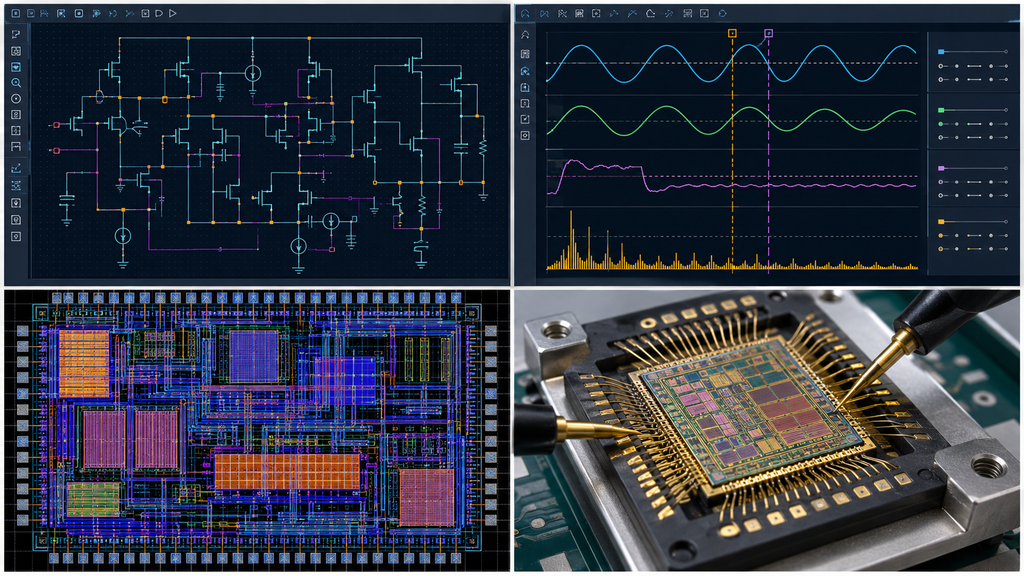

**01 电路设计**输入范围 · 噪声预算 · AFE/ADC

**02 仿真验证**PVT · 失配 · 噪声 · 建立时间

**03 版图与集成**匹配 · 供电分区 · 顶层接口

**04 芯片与测试**参考链路 · 校准 · 失效归因

**核心经验**一颗接口芯片的价值不只来自电路模块，而来自定义、测量、校准和测试能否形成闭环。

AI 生成去敏示意 · 只证明工作内容类别，不代表真实项目截图或具体芯片证据

## 传感器向芯片提供什么信号

02 · 气敏信号为何难读

**气体与环境条件**气体种类 · 浓度 · 温湿度 · 暴露时间

*›*

**材料与器件响应**不展开吸附机理，只观察电学变化

*›*

**芯片看到的输入**电阻 R(t) · 电压 V(t) · 电流 I(t)

**幅度**决定量程和增益

**偏置**决定输入结构与功耗

**时间**决定采样窗口和带宽

**历史**决定基线与校准边界

## 常温电阻式的系统边界

02 · 气敏信号为何难读

持续高温工作

**敏感器件***+***加热器***+***温控驱动***+***热耦合管理**

**功耗**持续加热成为系统负载

**场景**便携与电池供电受制约

**系统**需加热、温控和热隔离

**工艺**微热板常引入MEMS路径

常温候选路线

**敏感器件***+***读出接口***+***扫描与校准**

**功耗**可减少持续加热相关功耗

**场景**更容易进入小型与密集部署

**系统**读出、扫描和环境校准为主

**工艺**可研究标准CMOS加后处理

**条件性结论**常温路线在功耗、应用场景和系统集成上有潜在优势；前提是材料响应可重复、可恢复，且后处理与封装可行。

## 响应曲线如何变成芯片规格

02 · 气敏信号为何难读

**基线与变化量**输入范围 · 增益 · 动态范围

**响应与恢复时间**采样窗口 · 数据速率 · 观察时长

**噪声与漂移**有效分辨率 · 低频噪声 · 校准职责

**器件间分布**通道一致性 · 可编程范围 · 测试覆盖

## 实验室系统如何完成读出

02 · 气敏信号为何难读

[figure not shown]

气源*→*MFC / 混气*→*气室与传感器*→*偏置与测量*→*同步采集

**灵活**可快速替换器件和测量条件

**分散**设备、连接和校准分别存在

**扩展代价**通道增加后同步与数据管理更复杂

AI 生成的通用实验室系统，不代表某一实验室的唯一配置；精确连接仍以页面标签为准。

## 板级读出的扩展限制

单通道可以灵活搭建，阵列规模增加后，限制来自系统而不只是器件数量。

01

### 安装空间

**PCB***× N*连接器与走线

模拟器件、连接器和走线扩大 PCB，读出板可能比传感器更难放入目标位置。

市场线 · 需要真实场景与尺寸证据

02

### 系统成本

**BOM***+*装配与测试

通道增长同时增加器件、装配、测试和校准工作，集成收益需要系统级核算。

成本线 · 需要 BOM、面积、良率与测试数据

03

### 阵列一致性

**CH₁…CHₙ***≠*量程与基线

同步、量程、偏移与串扰决定通道能否比较，板级验证复杂度随阵列扩大。

技术线 · 芯片级寻址和校准是待验证路径

**阵列规模增加**器件与走线增加装配与测试增加同步、校准和串扰问题放大

通道数**1****8****16****32**板级单元*1×**8×**16×**32×*芯片公共模块*1组**1组**1组**1组*

概念模型；交叉点需BOM、die面积、良率、封装和测试数据确定

研究动机 阵列越大，越值得研究芯片级测量与校准，并不意味着板级方案不可用。

## 接口芯片需要解决的问题

02 · 气敏信号为何难读

材料与器件参数

转换关系

芯片规格类别

**基线阻值与变化范围**器件输出落在哪里

*›*

**输入范围**偏置、增益和量程

**慢响应与低频漂移**有效变化落在哪个频段

*›*

**噪声预算**1/f 噪声、温漂和带宽

**阵列与连接方式**通道怎样被选择和隔离

*›*

**通道隔离**开关、供电、时钟和串扰

**动态变化与基线**什么信息必须被保留

*›*

**转换精度**ADC 动态范围和有效分辨率

**器件差异与历史状态**哪些误差可以被识别

*›*

**校准能力**内部参考、参数和更新条件

本页定义问题类别，具体指标需要材料数据、噪声预算和设计验证共同确定。

## Touch IC 的多通道读出链路

03 · Touch IC 方法参考

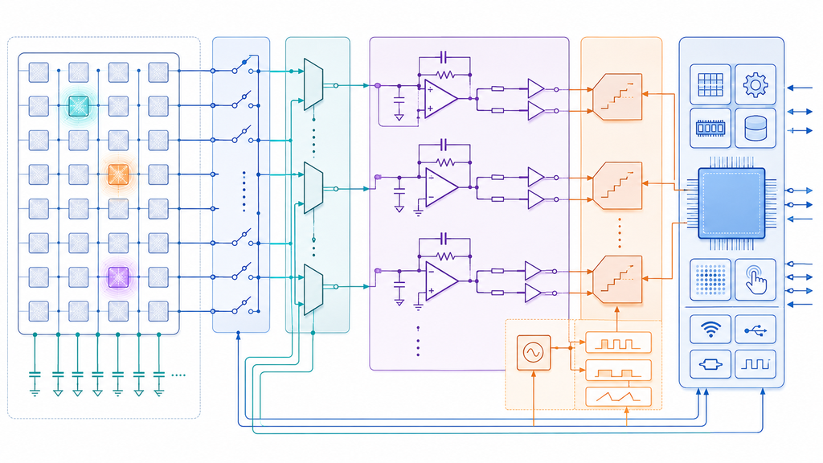

Sensor panel行列电极*↓*TX/RX 扫描选择与激励*↓*AFE Analog电荷积分与调理*↓*ADC转换为原始码*↓*DIGITAL基线 · 校准 · 通信

**DIGITAL**选择通道 · 配置激励 · 设置量程 · 安排校准**返回控制模拟测量**

**借鉴对象**多通道测量框架与工程方法**不能直接照搬**传感量、输入级、时间尺度和基线含义

## Touch IC 与气敏读出的迁移边界

Touch IC

可借鉴的方法

气敏接口芯片

**传感量**电容或电荷变化

统一测量模型

**传感量**电阻、电压或电流

**主要时序**快速扫描与显示干扰抑制

通道扫描与同步

**主要时序**慢响应中的低频噪声与漂移

**基线处理**围绕面板状态持续更新

误差分解与校准

**基线处理**区分芯片误差、环境与材料历史

**外部干扰**显示耦合、手指环境与批次偏差

噪声预算与通道隔离

**外部干扰**温湿度、低频漂移、接触与批次差异

**验证方法**扫描时序、基线更新与干扰抑制

PVT、失配与测试闭环

**验证方法**电学基准、参考链路与真实传感器联测

**迁移系统方法**多通道框架、误差分解和验证方法可以借鉴；器件模型、输入电路、采样窗口和校准边界必须重新建立

## 可以借鉴的工程方法

03 · Touch IC 方法参考

01

### 噪声预算

传感器、输入级、参考源、ADC 和数字处理分别分配噪声贡献。

回答：噪声来自哪一段

02

### 通道隔离

同时检查输入开关、走线、供电、衬底和数字时钟耦合。

回答：通道能否相互比较

03

### PVT 与失配

区分工艺、供电、温度、器件偏差，以及材料和封装差异。

回答：变化由谁造成

04

### 校准与测试闭环

定义内部参考、观察节点、参数来源、存储位置和更新时机。

回答：问题怎样被定位

**迁移边界**工程方法可以复用，气敏器件模型、输入参数和验收条件必须重新建立。

## 气敏读出系统全景

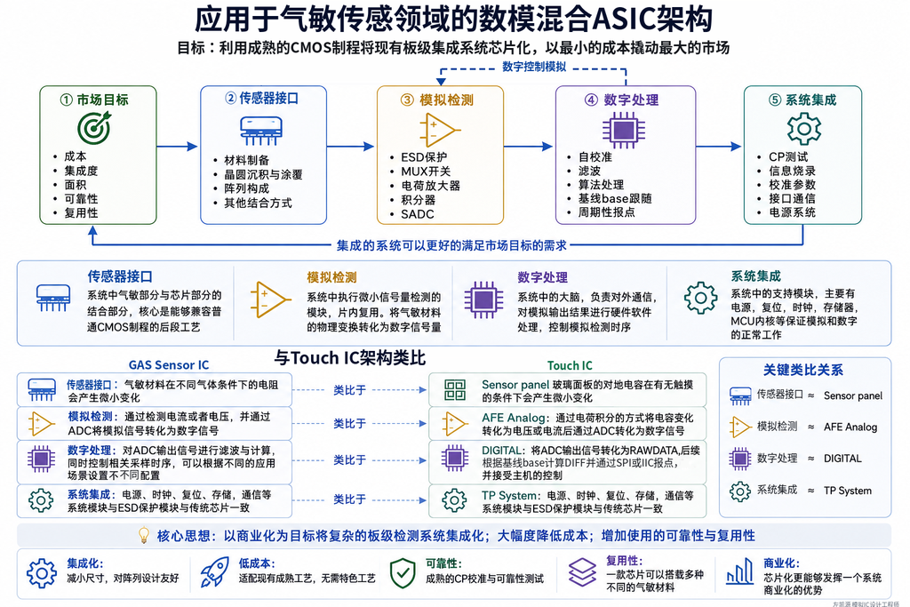

主链**传感器接口 · 模拟检测 · 数字处理 · 系统集成**

成本线**分立器件、连接与人工校准**

市场线**板级面积与封装限制**

技术线**阵列寻址、同步、校准与可靠性**

**控制方向：数字处理到模拟检测**

## 成本差异来自系统路径

04 · 从系统架构看成本

传统板级

**传感器***+***分立AFE/ADC***+***MCU***+***PCB与连接***+***装配校准**

通道增加时，器件、走线、装配和测试工作量同步增加。

MEMS气敏路径

**CMOS读出***+***MEMS微热板***+***键合/封装***+***加热与温控**

特殊工艺可解决热隔离，但可能同时保留CMOS和异质集成成本。

标准CMOS + 后处理假设

**公共AFE/ADC***+***数字校准***+***敏感材料沉积***+***统一测试**

核心机会是复用公共电路与测试链，后处理良率和封装仍需实证。

**16通道系统情景 · 作者工程估算**传统板级：约 **200元/套**CMOS集成：约 **33元/套**仅用于建立比较量级，传感器本体是否计入需在正式BOM中统一。

**必须同时计入**AFE / ADC · MCUPCB · 连接器 · 装联封装 · CP/FT测试 · 校准加热驱动与长期能耗（如需要）

**公开价格锚点 · 不是完整BOM**STM32C0：$0.21起 / 1万片经济型PCBA：$8.18建单费$0.0016 / 焊点，元件另计来源：ST与JLCPCB公开页面；实际采购、PCB和模拟器件仍待同批量询价。

**制造输入（作者估算）**90 nm 12英寸 CMOS：$1,000–2,000/片8英寸 MEMS：约$5,000/片**仅按圆片面积归一约5.6–11.3×；未计良率、掩膜、后处理、封装与测试。**

## 成本门槛改变可达市场

04 · 市场化是待验证假设

高成本 · 大体积 · 高功耗**应用门槛**小型化 · 低功耗 · 可量产

01**消费电子与可穿戴**

尺寸、电池寿命和单机成本构成入场门槛。

02**便携式气体检测**

从固定式工业仪器向轻量化、多点检测扩展。

03**食品品质与电子鼻**

阵列密度、一致采集和单次测试成本决定可用性。

04**室内空气监测**

长期稳定、多点部署和校准维护成本是关键。

**作者商业假设**跨过价格、体积和功耗门槛后，可达市场可能出现数量级甚至指数式扩张，但尚无价格—销量数据验证。

## 芯片化能改善哪些系统属性

04 · 可靠性来自可观测和可验证

统一芯片平台**参考 · 时序 · 状态记录**

01**可靠性**

减少外部连接和人工配置，统一供电、时钟和异常监测。

02**可标定性**

通过内部参考、环境通道和参数存储保留校准条件。

03**可测性**

使用测试模式、观察节点和电学基准区分故障层级。

04**复用性**

用可编程偏置、量程和扫描配置适配多种材料与阵列。

**必须验证**芯片化只是提供可能性；器件老化、污染、封装暴露和材料不可逆仍由联合实验回答。

## 传感器接口

04 · 拟议芯片架构

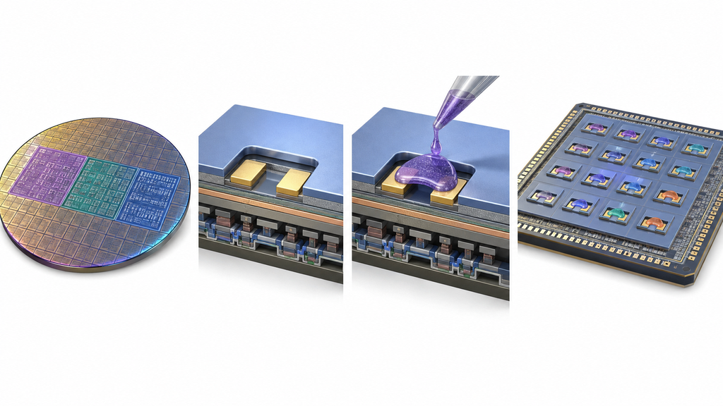

**01 标准 CMOS 晶圆**AFE · ADC · 数字 · 测试结构

*↓*

**02 PV 钝化层开孔**暴露两个金属电极

*↓*

**03 选择性材料沉积**在两个电极之间成膜

*↓*

**04 多材料阵列**不同区域使用不同敏感材料

**保守路径**外置传感器通过封装或PCB连接进入芯片

**研究假设**标准CMOS完成后，通过PV开孔和选择沉积形成阵列

**待验证**污染、温度预算、对准、良率、封装暴露和长期可靠性

**邻近工程证据****Nature 2025**复旦团队展示二维闪存器件与CMOS的系统集成DOI 10.1038/s41586-025-09621-8  
非气敏器件，不证明本路线已可量产

## 模拟前端的基本选择

04 · 拟议芯片架构

**先确定输入**阻值范围允许偏置变化幅度时间尺度

### 电阻/桥式读出

适合比较阻值变化和参考支路，关注匹配与桥路偏置。

### TIA / 电流读出

把传感器电流转换为电压，关注输入范围与反馈阻抗。

### 可编程增益链

覆盖器件分布和动态变化，关注切换瞬态与噪声。

**选择依据**输入范围低频噪声功耗与面积通道复用校准可观察性

## ADC 怎样保存有用变化

04 · 拟议芯片架构

大基线小变化 Δ*噪声与漂移*

**采样窗口**●●●●●●●

慢信号仍可能同时面对大基线、低频噪声和长期漂移

**输入范围**决定 ADC 需要覆盖的总动态范围

**噪声带宽**决定有效分辨率，不等同于标称位数

**采样速度**需覆盖响应过程、扫描时序和校准动作

**原始数据**保留通道、时间、量程和激励状态

具体位数和采样率是后续设计预算结果，本页只说明约束关系。

## 校准处理的职责边界

芯片负责

### 内部可测误差

偏移、增益、参考源变化、通道失配与电路温漂

**识别手段**内部参考 · 测试模式 · 存储参数

联合标定

### 传感器与接口组合基线

初始状态、参考通道、环境变量与校准更新条件

**识别手段**已知条件 · 参考通道 · 参数更新记录

材料实验定义边界

### 物理不可逆与长期变化

不可逆吸附、老化、接触变化与环境交叉敏感

**识别手段**材料实验 · 环境对照 · 长期跟踪

**校准参数存储****OTP**一次写入出厂参数**eFuse**少量修调与芯片ID**Flash**支持现场更新**外部NVM**适合多配置与追溯

校准需要先说明正在消除什么，否则可能把目标气体造成的慢变化一起删除。

## 数字控制模拟

04 · 拟议芯片架构

**传感器阵列**多通道电学变化

*›*

**模拟检测**MUX · 偏置 · 增益 · AFE

*›*

**ADC**原始数字码

*›*

**数字处理**状态、校准与数据组织

**数字控制模拟**选择通道 · 设置增益和偏置 · 确定采样窗口 · 启动校准 · 切换激励波形

**每个数据点同时记录**通道时间量程激励状态校准状态

这是测量闭环。主动扫描能否增加有效信息，需要在相同传感器与气体条件下对照验证。

## 常温路线能够简化什么

05 · 常温电阻式主线

高温工作系统

**传感器****加热器****温控驱动****热隔离****读出链**

*减少持续加热相关模块*

常温候选系统

**传感器****读出链****主动扫描****校准**

**功耗与电源**可能减少加热功率和驱动

**热耦合**可能减少阵列间热串扰

**封装与安装**可能降低热隔离与耐温约束

**成立前提**响应、恢复和长期稳定性可重复

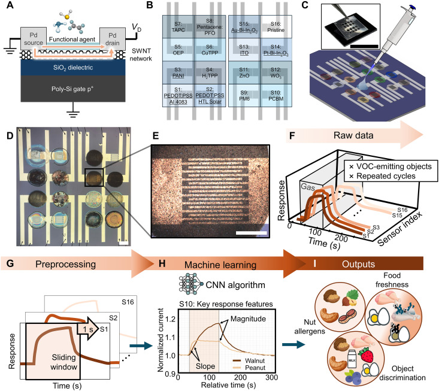

Berkeley 2026 · 原 Fig.1  
固定栅压下读取源漏电流变化，并展示16元件功能化阵列

**器件与读出边界**CNT-FET；固定栅压下测量源漏电流变化**接口层可类比电阻/电导读出，不改称普通电阻器件**Bassil et al., Science Advances 12, eaec7965 (2026) · DOI 10.1126/sciadv.aec7965

## 常温电阻式的材料风险

05 · 常温电阻式主线

**连续、可重复测量**项目最关键的不确定性

**脱附与恢复**能否回到可定义基线

**回滞**路径是否依赖历史

**氧化与老化**长期输出是否变化

**接触电阻**材料与电极能否区分

**湿度交叉敏感**环境是否覆盖目标信号

**器件分布**通道能否比较和校准

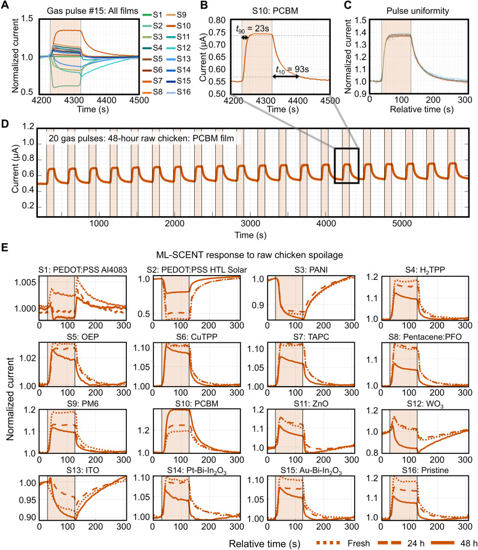

**邻近证据**CNT-FET 阵列的动态与重复性不替代本项目材料验证 · DOI 10.1126/sciadv.aec7965

**需要材料实验回答**可逆性长期稳定性环境条件样品分布参考通道策略

## MOS 管型气敏传感器：先定义对象

05 · 扩展器件形式

**“MOS 管型气敏传感器”**当前术语尚未定稿

A

### 气敏 FET

气体作用改变沟道、电荷或器件电流。

B

### 敏感栅 MOSFET

敏感栅或界面变化调制阈值与电流。

C

### 其他场效应结构

扩展栅、浮栅等耦合结构。

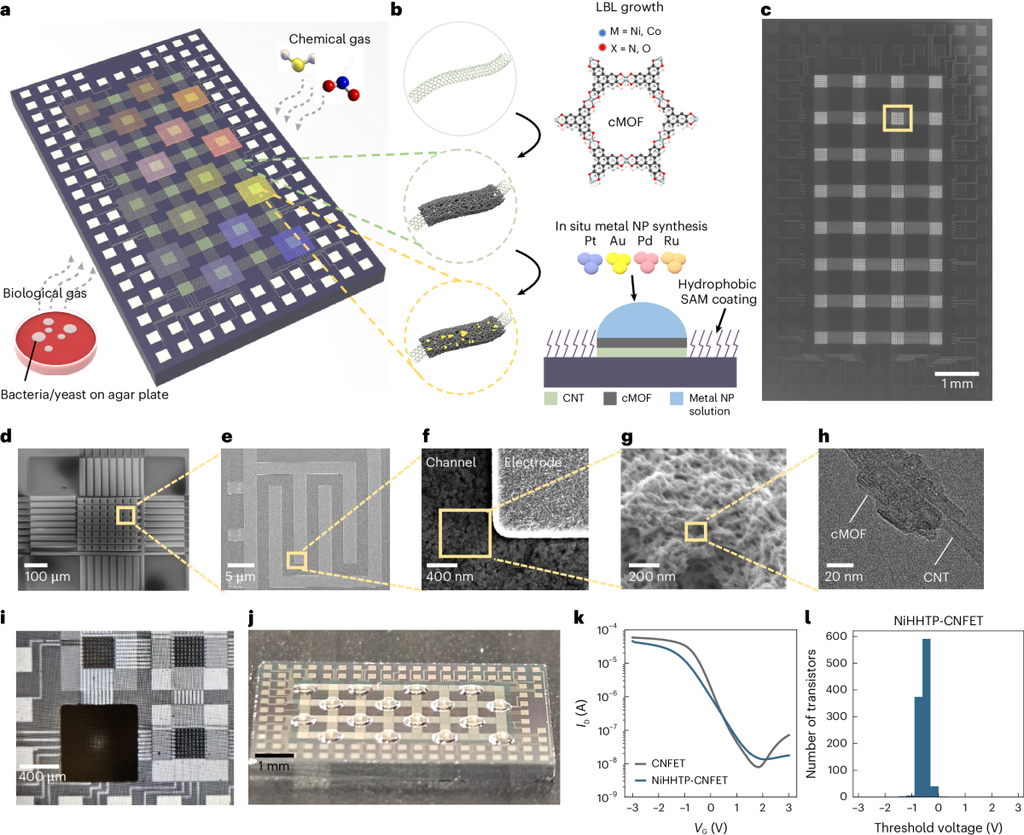

MIT 2026 · Fig.1：2,048个CNFET、32子阵列与功能化流程

**术语边界**MOX 常指金属氧化物材料；MOSFET 指晶体管结构，两者不能混用。

**证据边界**支持功能化场效应器件与大规模阵列集成CNFET不等于硅MOSFET，也不证明电容或K值路线优于电阻 · DOI 10.1038/s44460-026-00037-z

## 后续验证计划：先回答最小问题

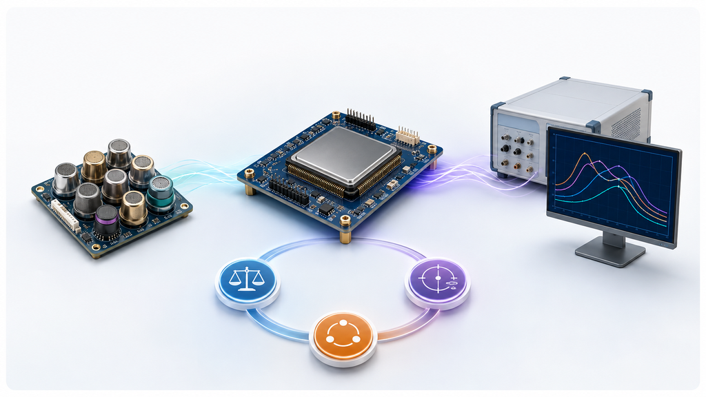

**01 能否测对**电学基准与真实器件趋势是否一致

**02 能否区分**芯片误差、材料变化与环境漂移能否归因

**03 是否值得扩展**少通道数据能否支持阵列化判断

**披露边界**本次仅说明后续将通过芯片验证测量闭环，不展开规格、模块配置、时间表或Demo实施细节。

## 可能失败在哪里

06 · 第一颗芯片如何验证

01

### 材料不可逆

基线无法恢复或长期持续变化

返回材料与环境实验

02

### 接口范围不匹配

偏置、阻值或动态变化超出可测范围

返回器件接口与量程定义

03

### 低频噪声占据变化

目标信号与温漂、1/f 噪声难以区分

返回噪声预算与采样窗口

04

### 通道耦合

开关、供电、时钟或版图污染相邻通道

返回隔离与扫描时序

05

### 校准模型失效

校准删掉有效变化或无法覆盖器件分布

返回误差分层与参考条件

**测试芯片的有效产出**即使路线失败，也应明确失败发生在哪一层，以及下一次迭代需要改变什么。

## 希望实验室讨论的问题

06 · 交流需要收敛的输入

Q1

### 接口数据

常温候选器件的实际阻值或电流范围、允许偏置、变化幅度和时间特征是什么？

输出：输入范围与采样假设

Q2

### 阵列条件

哪些材料和器件适合进入同一阵列，通道需要怎样同步，是否需要参考或环境通道？

输出：阵列结构与扫描假设

Q3

### 验证边界

哪些漂移可视为系统误差，哪些属于材料机理，怎样建立可逆性和长期稳定性判据？

输出：校准职责与停止条件

**现场记录**候选器件 / 数据范围 / 可提供样品 / 联测条件 / 关键反例

## 研究问题与下一步

01

### 问题入口

材料与器件经历定义传感器端，模拟 IC 工作定义芯片与验证端。

02

### 报告主线

常温电阻式器件进入可编程 AFE、ADC、校准和数字控制的测量闭环。

03

### 成立条件

材料可逆性、接口量程、低频噪声和误差归因必须经过联合验证。

**后续计划**补齐接口数据*›*建立可归因的电学基准*›*评估芯片化验证条件

接口芯片的价值，需要材料、电路和系统数据共同证明。

## 谢谢｜欢迎交流

THANK YOU

## 感谢聆听

欢迎从材料、器件、测试与芯片接口边界上交流

**左凯源***模拟 IC 设计工程师***微信：ZUOKAIYUANN**邮箱：zuokaiyuann@foxmail.com

2026.9.10